# Fishermana

Ideal Student Life Survey Student Responses Data for the Survey about Ideal Student Life and Key Factors

Youssef Khezami Khalil Boughzou Mouna Hmani

Link for Video presentation: https://drive.google.com/drive/folders/1AmzYizEc0DCb9hw8j69JAGY0JiGicicr

Background:  
Engagement surveys define student engagement as involvement in activities and conditions that are linked with the level of satisfaction of student in their lives. A key assumption is that a perfect studet life is influenced by how an individual participates in activities and events.

Section 1: What is the global context of the data?  
Understanding the psychology of students and understand their level of engagement and involvement in activities have a relation with their level of stress and satisfaction with their student life. This dataset consists of Student Responses to the survey about Ideal Student Life and key factors that are important in student life. Who has collected the data? The data was collected by Shivam Bansal a Data Scientist at H2O.ai Singapore. When has the data been collected? This Data has been posted on Kaggle in 2019 no further information was found. What are the features (Statistical variables) of the data? The first set of data can be divided into 4 parts: Descriptive statistics are used to describe the participants in a study (From 1 to 9) Questions about the engagement of students are explained with further details in the second section. (from Q1 to Q5) Rating for the level of engagement, stress, and Satisfaction ( Q6, Q7 and Q8) Free-format question to ask about the ideal student life. (Q9) The second set of data is going through more details from Q1 to Q5.

What are the instances (individuals) in the data? This sample of the data is taken from the National University of Singapore.

Section 2: The dataset can be used to answer key questions such as : -1)What factors lead to Stress, More Participation, More Interaction, More Satisfaction? -2)What factors lead to increased stress among the students? -3)What are the most important attributes for an Ideal Student Life?

The Questionnaire: Ideal Student Life Survey: 1 - Career 2 - Citizenship 3 - Nationality 4 - Year.since.Matriculation 5 - Year.of.Study 6 - Primary.Programme 7 - Gender 8 - Department 9 - Housing Type Q1.How.many.events.have.you.Volunteered.in. If yes please select from the list below: Animal welfare  
Arts/Culture/Heritage  
Children/Youth  
Community building  
Diversity & Inclusion  
Environmental sustainability  
Families  
Health/Well-being (e.g mental health)  
Seniors  
Poverty reduction  
Education  
Others Q2.How.many.events.have.you.Participated. in. If yes please select from the list below: Societies and Interest Groups Clubs  
Halls, JCRCs, and/or Residential College CSCs  
University organized events  
Others  
Q3.How.many.activities.are.you.Interested.in.. Arts & Culture  
Science & Technology  
Research and independent study  
Sports Other competitions (eg case, debates) Entrepreneurship Volunteering Others Q4.How.many.activities.are.you.Passionate.about.. Animal welfare  
Arts/Culture/Heritage  
Children/Youth  
Community building  
Diversity & Inclusion (e.g. special needs, migrant worker, interfaith and intercultural understanding) Environmental sustainability  
Families Health/Well-being (e.g mental health)  
Seniors  
Poverty reduction  
Education  
None of the above  
Others Q5.What.are.your.levels.of.stress.. Adjustment issues  
Academic issues  
Financial issues  
Family issues  
Friendships  
Romantic relationships  
Health-related issues  
Career-related issues  
My involvement in hostel, clubs, societies, interest groups, etc.  
Others  
Q6.How.Satisfied.You.are.with.your.Student.Life.. 0 Poor ; 1 Fair; 2 Good ; 3 Excellent Q7.How.much.effort.do.you.make.to.interact.with.others.. 0 Never ; 1 Sometimes; 2 Often; 3 Very often; 4 N/A  
Q8.About.How.events.are.you.aware.about.. Q9.What.is.an.ideal.student.life..

## Libraries

```python
import pandas as pd #manipulate the data
import numpy as np #use mathematical functions
from PIL import Image #generate graphs and images
from wordcloud import WordCloud, STOPWORDS, ImageColorGenerator # genearte wordcloud
import matplotlib.pyplot as plt # generate graphs and plots
import seaborn as sns # generate heatmap

from sklearn.tree import DecisionTreeClassifier # Import Decision Tree Classifier
from sklearn.model_selection import train_test_split # Import train_test_split function
from sklearn import metrics #Import scikit-learn metrics module for accuracy calculation
from sklearn.ensemble import RandomForestClassifier#Import RandomForest

from sklearn.linear_model import LogisticRegression#Import LogisticRegression
```

## Data Input & Cleaning

```python
dataframe = pd.read_csv('./survey_questions_meta.csv')
surveymain = pd.read_csv('./survey_responses.csv')
del dataframe['response_id']
del surveymain['response_id']
```

```
Interpreation: We have removed the response_id because it is irrelevant to the models we intend to use.
```

### Data Summary

```python
dataframe.describe()
```

|  | Q1-Volunteered For Animal welfare | Q1-Volunteered For Arts/Culture/Heritage | Q1-Volunteered For Children/Youth | Q1-Volunteered For Community building | Q1-Volunteered For Diversity & Inclusion | Q1-Volunteered For Environmental sustainability | Q1-Volunteered For Families | Q1-Volunteered For Health/Well-being (e.g mental health) | Q1-Volunteered For Seniors | Q1-Volunteered For Poverty reduction | ... | Q5-Stressed about Adjustment issues | Q5-Stressed about Academic issues | Q5-Stressed about Financial issues | Q5-Stressed about Family issues | Q5-Stressed about Friendships | Q5-Stressed about Romantic relationships | Q5-Stressed about Health related issues | Q5-Stressed about Career related issues | Q5-Stressed about My involvement in hostel, clubs, societies, interest groups, etc. | Q5-Stressed about Others |
| --- | --- | --- | --- | --- | --- | --- | --- | --- | --- | --- | --- | --- | --- | --- | --- | --- | --- | --- | --- | --- | --- |
| count | 1687 | 1687 | 1687 | 1687 | 1687 | 1687 | 1687 | 1687 | 1687 | 1687 | ... | 2958 | 2958 | 2958 | 2958 | 2958 | 2958 | 2958 | 2958 | 2958 | 2958 |
| unique | 2 | 2 | 2 | 2 | 2 | 2 | 2 | 2 | 2 | 2 | ... | 2 | 2 | 2 | 2 | 2 | 2 | 2 | 2 | 2 | 2 |
| top | No | No | No | No | No | No | No | No | No | No | ... | No | Yes | No | No | No | No | No | No | No | No |
| freq | 1542 | 1555 | 923 | 1224 | 1291 | 1528 | 1512 | 1351 | 1097 | 1515 | ... | 2051 | 2728 | 1816 | 2522 | 2160 | 2468 | 2511 | 1612 | 2147 | 2917 |

4 rows × 48 columns

```python
surveymain.describe()
```

|  | Year since Matriculation | Year of Study | Q1-How many events have you Volunteered in ? | Q2-How many events have you Participated in ? | Q3-How many activities are you Interested in ? | Q4-How many activities are you Passionate about ? | Q5-What are your levels of stress ? | Q6-How Satisfied You are with your Student Life ? | Q7-How much effort do you make to interact with others ? | Q8-About How events are you aware about ? |
| --- | --- | --- | --- | --- | --- | --- | --- | --- | --- | --- |
| count | 2958.000000 | 2958.000000 | 2958.000000 | 2958.000000 | 2958.000000 | 2958.000000 | 2958.000000 | 2958.000000 | 2940.000000 | 2940.000000 |
| mean | 2.207235 | 2.206220 | 1.248141 | 1.493577 | 2.733942 | 3.184246 | 3.091954 | 1.925287 | 1.963265 | 2.082993 |
| std | 1.102763 | 1.099729 | 1.480097 | 0.958274 | 1.269236 | 1.969894 | 1.653537 | 0.562162 | 0.575096 | 0.642636 |
| min | 1.000000 | 1.000000 | 0.000000 | 0.000000 | 1.000000 | 0.000000 | 0.000000 | 0.000000 | 0.000000 | 1.000000 |
| 25% | 1.000000 | 1.000000 | 0.000000 | 1.000000 | 2.000000 | 2.000000 | 2.000000 | 2.000000 | 2.000000 | 2.000000 |
| 50% | 2.000000 | 2.000000 | 1.000000 | 1.000000 | 3.000000 | 3.000000 | 3.000000 | 2.000000 | 2.000000 | 2.000000 |
| 75% | 3.000000 | 3.000000 | 2.000000 | 2.000000 | 3.000000 | 4.000000 | 4.000000 | 2.000000 | 2.000000 | 2.000000 |
| max | 6.000000 | 5.000000 | 11.000000 | 5.000000 | 8.000000 | 11.000000 | 9.000000 | 3.000000 | 3.000000 | 4.000000 |

```
Interpretation: These are both the summaries of the first and second dataset. We will proceed to check for outliers in the data.
Outliers increase the variability in our data, which decreases statistical power. Consequently,excluding outliers can cause our results to become statistically significant.
Visually, we have outliers since the Maximum value is > mean + std but we'll still check statistically
```

### Boxplot

We used boxplot to identifiy outliers

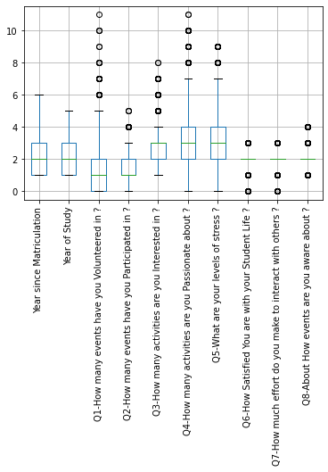

```python
surveymain.boxplot(rot=90)
```

```
Interpretation: Indeed, we have outliers that we need to eliminate.
```

### Elimination of outliers using Boxplot

```python
surveymain = surveymain[surveymain['Q1-How many events have you Volunteered in ?'] < 6]
surveymain = surveymain[surveymain['Q2-How many events have you Participated in ?'] < 4]
surveymain = surveymain[surveymain['Q3-How many activities are you Interested in ?'] < 4]
surveymain = surveymain[surveymain['Q4-How many activities are you Passionate about ?'] < 8]
surveymain = surveymain[surveymain['Q5-What are your levels of stress ?'] < 7]
surveymain.describe()
```

|  | Year since Matriculation | Year of Study | Q1-How many events have you Volunteered in ? | Q2-How many events have you Participated in ? | Q3-How many activities are you Interested in ? | Q4-How many activities are you Passionate about ? | Q5-What are your levels of stress ? | Q6-How Satisfied You are with your Student Life ? | Q7-How much effort do you make to interact with others ? | Q8-About How events are you aware about ? |
| --- | --- | --- | --- | --- | --- | --- | --- | --- | --- | --- |
| count | 2078.000000 | 2078.000000 | 2078.000000 | 2078.000000 | 2078.000000 | 2078.000000 | 2078.000000 | 2078.000000 | 2071.000000 | 2071.000000 |
| mean | 2.217517 | 2.217036 | 1.039942 | 1.314244 | 2.141482 | 2.697305 | 2.753609 | 1.914341 | 1.933848 | 2.095123 |
| std | 1.097483 | 1.096042 | 1.218870 | 0.849764 | 0.760231 | 1.488943 | 1.350092 | 0.551949 | 0.570591 | 0.627956 |
| min | 1.000000 | 1.000000 | 0.000000 | 0.000000 | 1.000000 | 0.000000 | 0.000000 | 0.000000 | 0.000000 | 1.000000 |
| 25% | 1.000000 | 1.000000 | 0.000000 | 1.000000 | 2.000000 | 2.000000 | 2.000000 | 2.000000 | 2.000000 | 2.000000 |
| 50% | 2.000000 | 2.000000 | 1.000000 | 1.000000 | 2.000000 | 2.000000 | 3.000000 | 2.000000 | 2.000000 | 2.000000 |
| 75% | 3.000000 | 3.000000 | 2.000000 | 2.000000 | 3.000000 | 4.000000 | 4.000000 | 2.000000 | 2.000000 | 2.000000 |
| max | 6.000000 | 5.000000 | 5.000000 | 3.000000 | 3.000000 | 7.000000 | 6.000000 | 3.000000 | 3.000000 | 4.000000 |

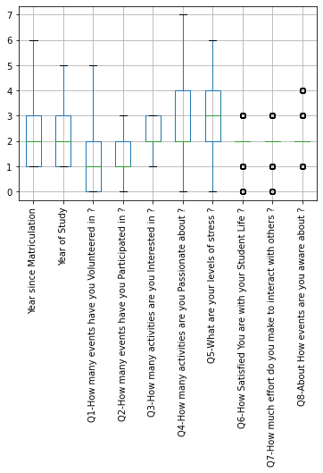

```python
surveymain.boxplot(rot=90)
```

[output not shown]

### Cleaning the names of the variables

```python
plotdict = {}
subs = {
    'Q1': 'Volunteered For ',
    'Q2': 'Participated in ',
    'Q3': 'Interested in ',
    'Q4': 'Passionate about ',
    'Q5': 'Stressed about '
}
```

`Interpetation: We changed the name of the questions to ensure a better visual representations of the data in the plotting`.

### Q1 -Visualization of how many people volunteered,participated in,interested in,passionate about and stressed about

```
we are interested in  knowing what activities are mostly done, participated in, interested in, passionate about and stressed about what factors
```

```python
for col in dataframe.columns:
    subdf = dataframe[col][dataframe[col] == "Yes"]

    numqs, question = col.split("-", 1)
    question = question.replace(subs[numqs], "")
    if numqs not in plotdict:
        plotdict[numqs] = {}
    plotdict[numqs][question] = len(subdf)
```

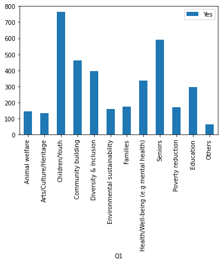

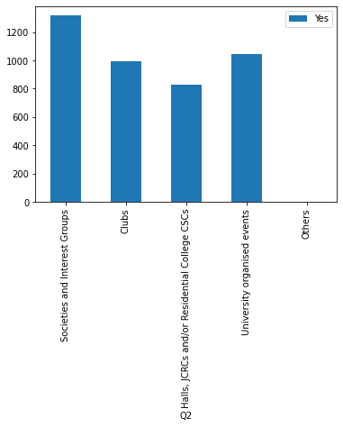

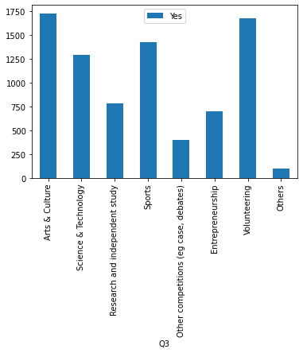

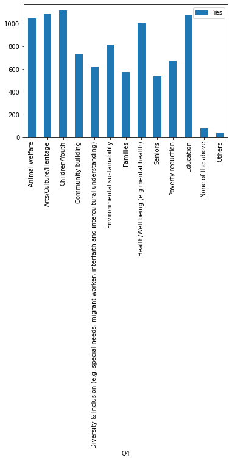

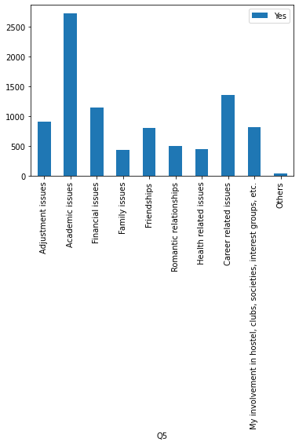

```python
for numqs, question in plotdict.items():
    df = pd.DataFrame({numqs:question.keys(), 'Yes':question.values()})
    ax = df.plot.bar(x=numqs, y='Yes', rot=90)
```

[output not shown]

### Q2 Finding the correlation + Visualization of the plot

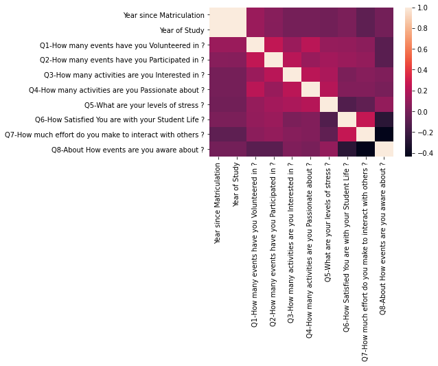

```python
correlations = surveymain.corr()
sns.heatmap(correlations)
```

[output not shown]

### WordCloud : Visualization of the most used words in the feedbacks of the ideal life

```python
stopwords = ["i", "nan", "one", "me", "my", "myself", "we", "our", "ours", "ourselves", "you", "your", "yours", "yourself", "yourselves", "he", "him", "his", "himself", "she", "her", "hers", "herself", "it", "its", "itself", "they", "them", "their", "theirs", "themselves", "what", "which", "who", "whom", "this", "that", "these", "those", "am", "is", "are", "was", "were", "be", "been", "being", "have", "has", "had", "having", "do", "does", "did", "doing", "a", "an", "the", "and", "but", "if", "or", "because", "as", "until", "while", "of", "at", "by", "for", "with", "about", "against", "between", "into", "through", "during", "before", "after", "above", "below", "to", "from", "up", "down", "in", "out", "on", "off", "over", "under", "again", "further", "then", "once", "here", "there", "when", "where", "why", "how", "all", "any", "both", "each", "few", "more", "most", "other", "some", "such", "no", "nor", "not", "only", "own", "same", "so", "than", "too", "very", "s", "t", "can", "will", "just", "don", "should", "now"]
```

```
<class 'list'>
```

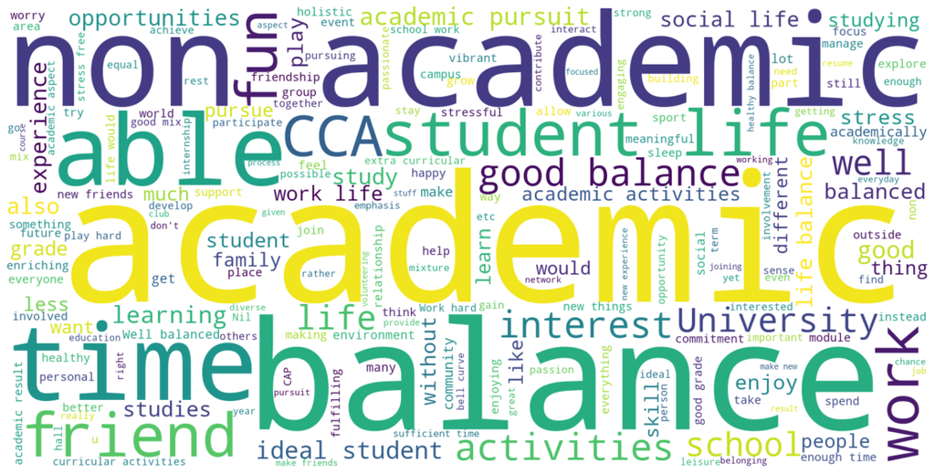

```python
listxt = surveymain['Q9-What is an ideal student life ?'].tolist()
print(type(listxt))
text = "#".join(map(str, listxt))
wordcloud = WordCloud(width=1600, height=800,stopwords=stopwords, background_color="white").generate(text)

# Display the generated image:
# the matplotlib way:
plt.figure( figsize=(20,10) )
plt.imshow(wordcloud, interpolation='bilinear')
plt.axis("off")
plt.show()
```

```
Interpretation: Here is a WordCloud of the text of every student in the ideal studennt column.
    As we can see the most used words are the ones with the bigger fontsize.
    For eg : Students mostly use balance;academic;non academic;time ; friend and able.
```

```
### Q3 Text Mining using the most used words
```

```python
criterions = ['stress', 'activities', 'academic', 'balanced', 'friendships']
keywords = {
    'stress': ['stress', 'personal'],
    'activites': ['activit', 'cca', 'social', 'work'],
    'academic': ['academ', 'stud', 'grad', 'learn'],
    'balanced': ['balanc'],
    'friendships': ['friend', 'fun', 'make']
}
varList = []
```

```
Interpretation: We divided the ideal student life into 5 attributes/categoties: Stundents are interested in doing activites +/ making friendship +/ their academic knowledge +/ a stress-free life or a balanced student life.
-Based on the WordCloud we got the most used words , classified and added them into lists for every attribites.
```

```python
for answer in surveymain['Q9-What is an ideal student life ?']:
    verdict = []

    for criterion, texts in keywords.items():
        critfound = False
        for text in texts:


            if text in str(answer).lower():

                verdict.append(1)
                critfound = True
                break
        if critfound == False:
            verdict.append(0)
        varList.append(verdict)
```

[output not shown]

### Logistic regresssion to predict the gender

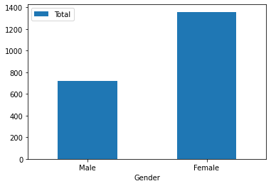

```python
surveymain.loc[surveymain['Gender'] == "F", 'Gender'] = 1
surveymain.loc[surveymain['Gender'] == "M", 'Gender'] = 0

surveymain
df_class_0 = surveymain[surveymain['Gender'] == 0]
df_class_1 = surveymain[surveymain['Gender'] == 1]
drawGender = pd.DataFrame({'Gender':['Male', 'Female'], 'Total':[len(df_class_0), len(df_class_1)]})
genderPlot = drawGender.plot.bar(x='Gender', y='Total', rot=0)
```

Interpretation: The dataset contains far more female persons than male persons therefore we need to clean it in order to balance the data.

```python
numMan = len(df_class_0)

df_class_1_under = df_class_1.sample(numMan)


surveymain = pd.concat([df_class_0, df_class_1_under], axis=0)
```

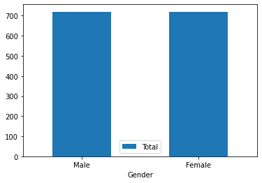

```python
df_class_0 = surveymain[surveymain['Gender'] == 0]
df_class_1 = surveymain[surveymain['Gender'] == 1]
drawGender = pd.DataFrame({'Gender':['Male', 'Female'], 'Total':[len(df_class_0), len(df_class_1)]})
genderPlot = drawGender.plot.bar(x='Gender', y='Total', rot=0)
```

```python
for col in surveymain.columns:
    surveymain[col] = surveymain[col].fillna(0)
```

```
Accuracy: 0.5777777777777777
```

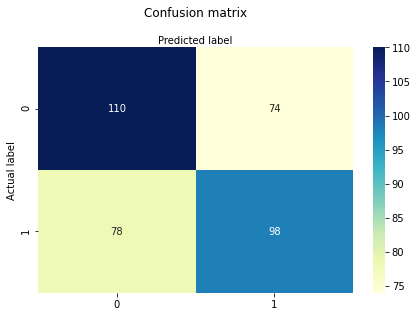

```python
col_names = ['Q1-How many events have you Volunteered in ?', 'Q2-How many events have you Participated in ?', 'Q3-How many activities are you Interested in ?', 'Q4-How many activities are you Passionate about ?', 'Q5-What are your levels of stress ?', 'Q6-How Satisfied You are with your Student Life ?', 'Q7-How much effort do you make to interact with others ?', 'Q8-About How events are you aware about ?']
X = surveymain[col_names]
Y = surveymain['Gender']


X_train,X_test,Y_train,Y_test=train_test_split(X,Y,test_size=0.25,random_state=0)

logreg = LogisticRegression()


# fit the model with data
logreg.fit(X_train,Y_train)
Y_pred=logreg.predict(X_test)


print("Accuracy:",metrics.accuracy_score(Y_test, Y_pred))
y_pred=logreg.predict(X_test)
cnf_matrix = metrics.confusion_matrix(Y_test, Y_pred)
cnf_matrix
class_names=["Male","Female"] # name  of classes
fig, ax = plt.subplots()
tick_marks = np.arange(len(class_names))
plt.xticks(tick_marks, class_names)
plt.yticks(tick_marks, class_names)
# create heatmap
sns.heatmap(pd.DataFrame(cnf_matrix), annot=True, cmap="YlGnBu" ,fmt='g')
ax.xaxis.set_label_position("top")
plt.tight_layout()
plt.title('Confusion matrix', y=1.1)
plt.ylabel('Actual label')
plt.xlabel('Predicted label')
```

### Random Forest to predict the gender

```
Accuracy: 0.5527777777777778
```

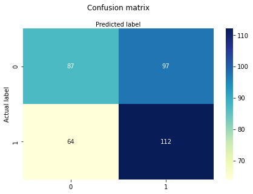

```python
clfc=RandomForestClassifier(n_estimators=100)

#Train the model using the training sets y_pred=clf.predict(X_test)
clfc.fit(X_train,Y_train)

Y_predx=clfc.predict(X_test)

print("Accuracy:",metrics.accuracy_score(Y_test, Y_predx))
cnf_matrix = metrics.confusion_matrix(Y_test, Y_predx)
cnf_matrix
class_names=["Male","Female"] # name  of classes
fig, ax = plt.subplots()
tick_marks = np.arange(len(class_names))
plt.xticks(tick_marks, class_names)
plt.yticks(tick_marks, class_names)
# create heatmap
sns.heatmap(pd.DataFrame(cnf_matrix), annot=True, cmap="YlGnBu" ,fmt='g')
ax.xaxis.set_label_position("top")
plt.tight_layout()
plt.title('Confusion matrix', y=1.1)
plt.ylabel('Actual label')
plt.xlabel('Predicted label')
```